# Count based regression models

## Alternative prior for theta

Let’s try a gamma(1, 0.1) prior. Gamma distributions have support only on positive values. Also, there is discussion online how weak priors like a gamma(0.01, 0.01) put too much support on values close to 0 (large overdisperions)

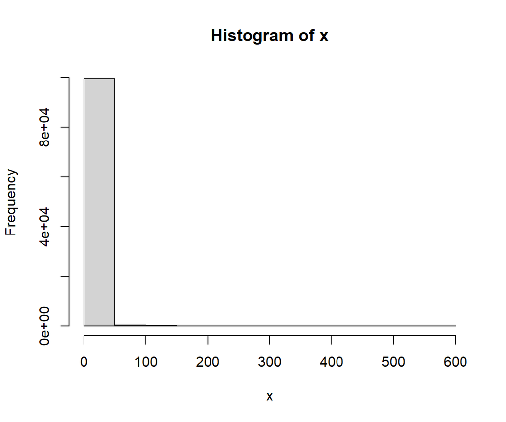

```r
x<-rgamma(100000, 0.01, 0.01)
hist(x)
```

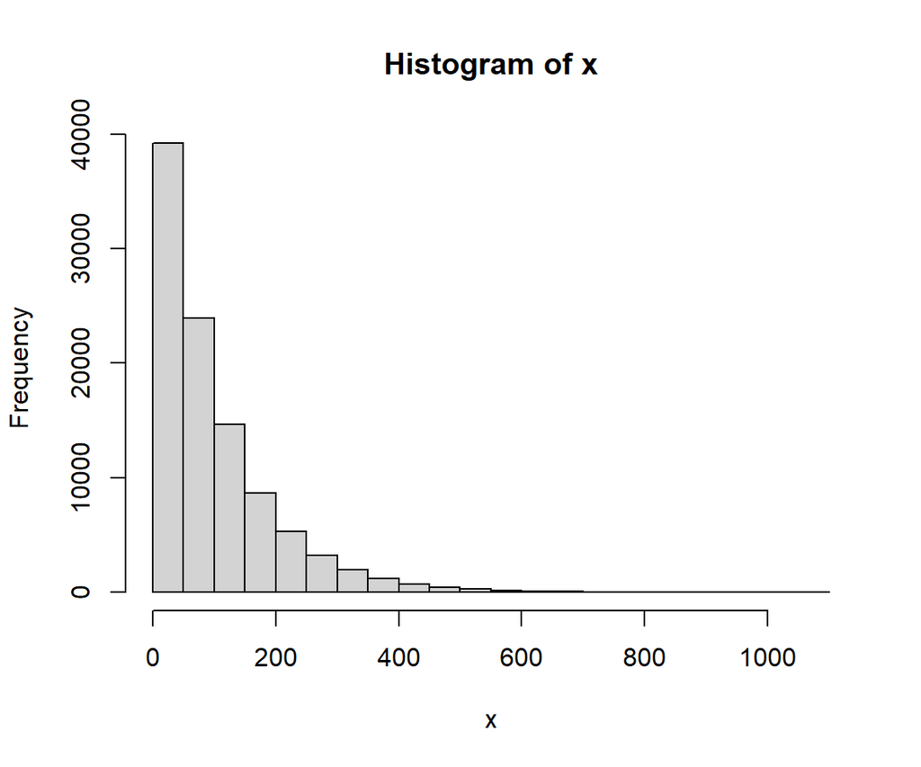

```r
x<-rgamma(100000, 1, 0.01)
hist(x)
```

## Fit negative binomial model using JAGS

```r
nb.fit2<-function(){

  # Priors for regression parameters
  for(i in 1:np){
    beta[i] ~ dnorm(0,0.001)
  }
  theta~dgamma(1, 0.1)
  for(i in 1:n){
    log(mu[i]) <- inprod(beta[], x[i,])
    p[i] <- theta/(theta+mu[i])
    longnosedace[i] ~ dnegbin(p[i],theta)

    # Fit assessments
    Presi[i] <- (longnosedace[i] - mu[i]) / sqrt(mu[i]+mu[i]*mu[i]/theta) # Pearson residuals
    dace.new[i] ~ dnegbin(p[i],theta)    # Replicate data set
    Presi.new[i] <- (dace.new[i] - mu[i]) / sqrt(mu[i]+mu[i]*mu[i]/theta) # Pearson residuals
    D[i] <- pow(Presi[i], 2)
    D.new[i] <- pow(Presi.new[i], 2)
  }

  # Add up discrepancy measures
  fit <- sum(D[])
  fit.new <- sum(D.new[])
}


# Parameters to estimate
params <- c("mu", "beta", "theta","Presi", "fit", "fit.new", "dace.new")


# Start Gibbs sampler
out.nb2 <- jags.parallel(data = jagsdata, parameters.to.save = params,
                        model.file = nb.fit2, n.thin = 2, n.chains = 3, n.burnin = 5000,
                        n.iter = 20000)
```

Density and trace plots

```r
MCMCsummary(out.nb2, params = "beta")
```

```
##                  mean           sd          2.5%           50%         97.5%
## beta[1] -2.955073e+00 1.503561e+00 -6.061074e+00 -2.8942790955 -2.288240e-01
## beta[2]  4.754723e-05 1.415389e-05  2.112222e-05  0.0000472653  7.653393e-05
## beta[3]  3.428714e-01 1.270218e-01  1.108512e-01  0.3377865385  6.058134e-01
## beta[4]  9.704678e-03 3.634835e-03  2.801535e-03  0.0096325176  1.709857e-02
## beta[5]  2.096738e-01 5.888735e-02  9.695846e-02  0.2085761420  3.288595e-01
## beta[6]  2.657300e-04 1.528766e-02 -2.811617e-02 -0.0002852807  3.179769e-02
## beta[7]  9.347290e-02 3.557765e-02  2.437885e-02  0.0928915859  1.621001e-01
##         Rhat n.eff
## beta[1] 1.03    86
## beta[2] 1.00  7038
## beta[3] 1.01   143
## beta[4] 1.00  2361
## beta[5] 1.00  5686
## beta[6] 1.00  4275
## beta[7] 1.01   420
```

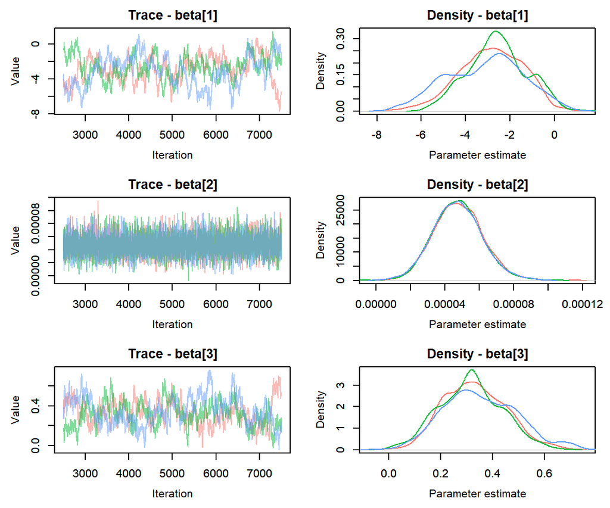

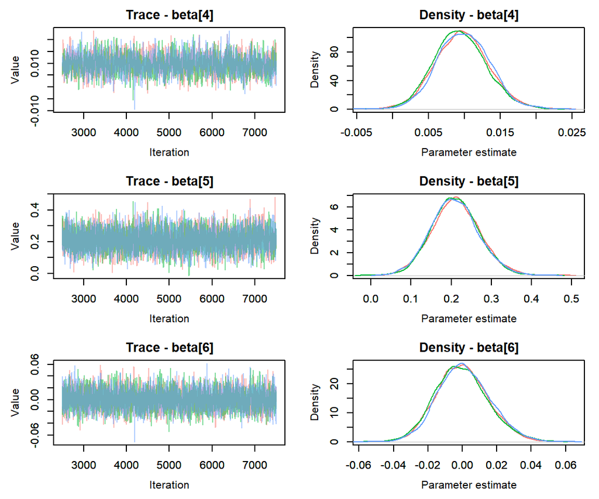

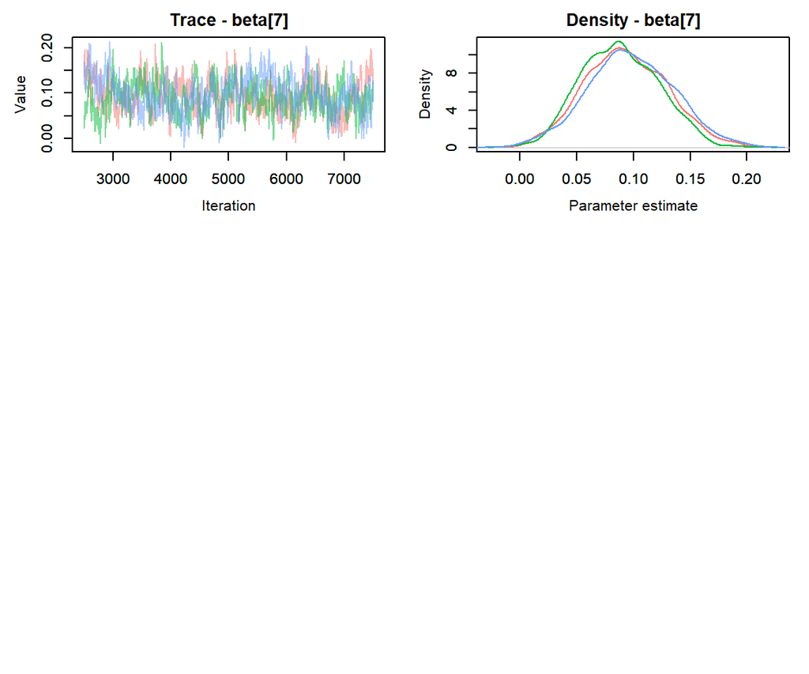

```r
MCMCtrace(out.nb2, pdf=FALSE, ind = TRUE, params = "beta")
```

Compare posteriors for theta using the two different priors

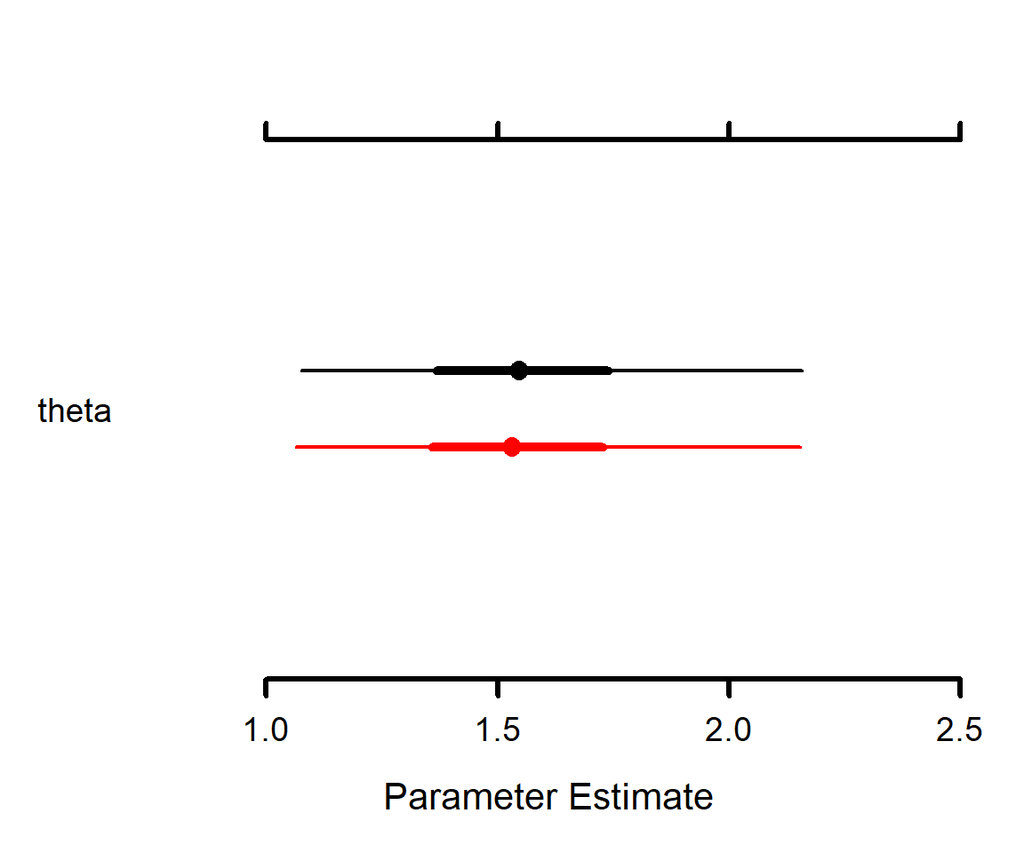

```r
MCMCplot(out.nb, out.nb2, param = "theta")
```

Fit Poisson-normal model using JAGS

```r
poisnorm.fit<-function(){

  # Priors for regression parameters
  for(i in 1:np){
    beta[i] ~ dnorm(0,0.001)
  }

  # Prior for sigma and tau
  sig ~ dunif(0, 3)
  tau <- 1/(sig*sig)


  for(i in 1:n){
    # Likelihood
    log(lambda[i]) <- inprod(beta[], x[i,]) + eps[i]
    longnosedace[i] ~ dpois(lambda[i])
    eps[i] ~ dnorm(0, tau)

    # Calculate mean and variance
    mu[i] <-  exp(inprod(beta[], x[i,]) + sig^2/2)
    vary[i] <- mu[i] + (exp(sig^2)-1)*mu[i]^2

    # Fit assessments
    Presi[i] <- (longnosedace[i] - mu[i]) / sqrt(vary[i]) # Pearson residuals
    dace.new[i] ~ dpois(lambda[i])    # Replicate data set
    Presi.new[i] <- (dace.new[i] - mu[i]) / sqrt(vary[i]) # Pearson residuals
    D[i] <- pow(Presi[i], 2)
    D.new[i] <- pow(Presi.new[i], 2)
  }

  # Add up discrepancy measures
  fit <- sum(D[])
  fit.new <- sum(D.new[])
}

# Parameters to estimate
params <- c("beta", "mu", "Presi", "fit", "fit.new")


# Start Gibbs sampler
out.poisnorm <- jags.parallel(data = jagsdata, parameters.to.save = params,
                              model.file = poisnorm.fit, n.thin = 2, n.chains = 3, n.burnin = 5000,
                              n.iter = 20000)
```

Density and trace plots

```r
MCMCsummary(out.poisnorm, params = "beta")
```

```
##                  mean           sd          2.5%           50%         97.5%
## beta[1] -3.3079132668 1.534860e+00 -6.323472e+00 -3.3064944299 -3.264344e-01
## beta[2]  0.0000489788 1.521537e-05  1.899396e-05  0.0000489332  7.851557e-05
## beta[3]  0.3619981740 1.229249e-01  1.233607e-01  0.3603522219  6.056820e-01
## beta[4]  0.0085122558 4.010267e-03  7.291542e-04  0.0084961160  1.650134e-02
## beta[5]  0.2002854039 6.496520e-02  7.328062e-02  0.2005192933  3.290316e-01
## beta[6]  0.0047955107 1.758835e-02 -3.011681e-02  0.0047667771  3.959647e-02
## beta[7]  0.0870741875 3.879502e-02  1.102475e-02  0.0870951835  1.639751e-01
##         Rhat n.eff
## beta[1]    1 18400
## beta[2]    1 21438
## beta[3]    1 19082
## beta[4]    1 19428
## beta[5]    1 19548
## beta[6]    1 21441
## beta[7]    1 20122
```

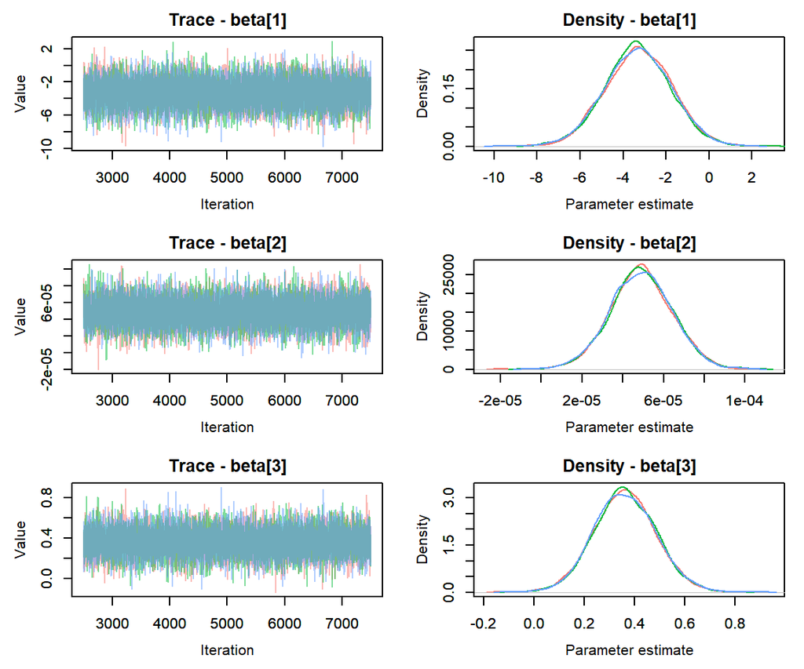

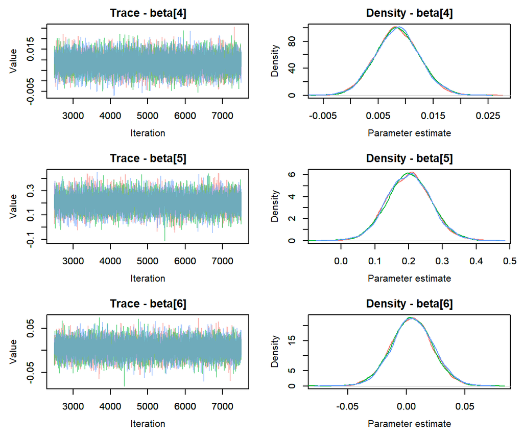

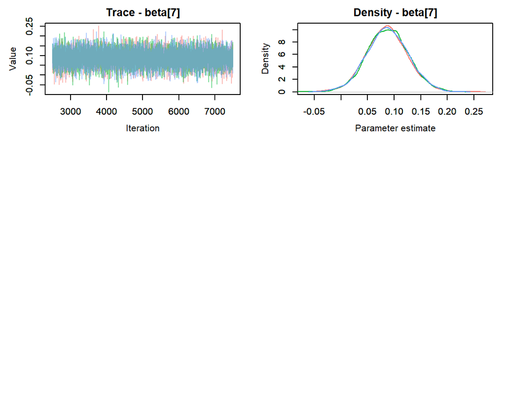

```r
MCMCtrace(out.poisnorm, pdf=FALSE, ind = TRUE, params = "beta")
```

Pearson residuals versus fitted values for the Poisson-Normal regression model

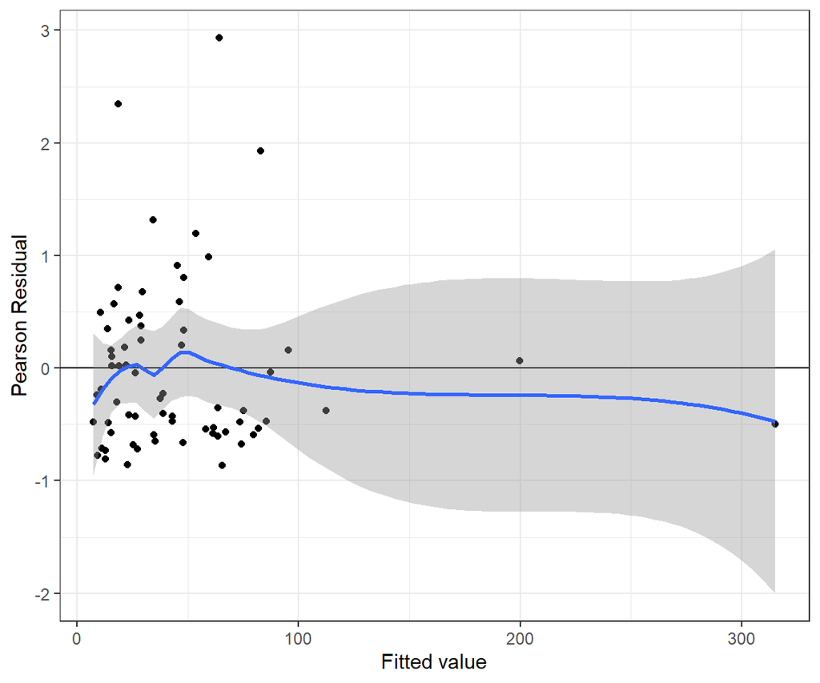

```r
pnresids <- MCMCpstr(out.poisnorm, params = "Presi", func = mean)$Presi
pnfitted <- MCMCpstr(out.poisnorm, params = "mu", func = mean)$mu
jagspnfit <- data.frame(resid = pnresids, fitted = pnfitted)
ggplot(jagspnfit, aes(fitted, resid)) + geom_point() +
  geom_hline(yintercept = 0) + geom_smooth() +
  xlab("Fitted value") + ylab("Pearson Residual")
```

GOF

```r
fitstats <- MCMCpstr(out.poisnorm, params = c("fit", "fit.new"), type = "chains")
T.extreme <- fitstats$fit.new >= fitstats$fit
(p.val <- mean(T.extreme))
```

```
## [1] 0.5251111
```

Comparisons using DIC

```r
out.pois$BUGSoutput$DIC
```

```
## [1] 2469.441
```

```r
out.nb$BUGSoutput$DIC
```

```
## [1] 610.5876
```

```r
out.poisnorm$BUGSoutput$DIC
```

```
## [1] 471.8213
```